# IE 48B Project Report

## Combined Models

Finally, combined linear regression model is trained and its results are as follows:

```r
comb1 <- lm(net ~ hour + is_monday + is_wday + is_friday + is_saturday + is_sunday + lag_24 + lag_168 + last_obs,train)
summary(comb1)
```

```
Call:
lm(formula = net ~ hour + is_monday + is_wday + is_friday + is_saturday +
    is_sunday + lag_24 + lag_168 + last_obs, data = train)

Residuals:
    Min      1Q  Median      3Q     Max
-3572.4  -488.7   -18.5   460.4  6377.9

Coefficients: (1 not defined because of singularities)
              Estimate Std. Error t value Pr(>|t|)
(Intercept) -7.357e+01  2.589e+01  -2.842 0.004488 **
hour1        1.103e+02  3.274e+01   3.369 0.000755 ***
hour2        5.948e+01  3.273e+01   1.818 0.069148 .
hour3       -2.801e+00  3.272e+01  -0.086 0.931767
hour4       -8.690e+01  3.279e+01  -2.650 0.008050 **
hour5       -1.004e+02  3.279e+01  -3.063 0.002191 **
hour6       -1.790e+02  3.290e+01  -5.441 5.33e-08 ***
hour7       -7.171e+01  3.274e+01  -2.191 0.028492 *
hour8       -2.362e+01  3.275e+01  -0.721 0.470735
hour9        1.359e+02  3.276e+01   4.148 3.36e-05 ***
hour10       1.348e+02  3.275e+01   4.115 3.88e-05 ***
hour11       2.194e+02  3.280e+01   6.688 2.31e-11 ***
hour12       1.243e+02  3.274e+01   3.797 0.000147 ***
hour13       8.646e+01  3.273e+01   2.642 0.008250 **
hour14       2.259e+02  3.281e+01   6.885 5.89e-12 ***
hour15       2.361e+02  3.280e+01   7.197 6.31e-13 ***
hour16       2.044e+02  3.277e+01   6.237 4.52e-10 ***
hour17       2.190e+02  3.280e+01   6.676 2.51e-11 ***
hour18       1.881e+02  3.280e+01   5.737 9.76e-09 ***
hour19       1.798e+02  3.280e+01   5.483 4.23e-08 ***
hour20       1.618e+02  3.280e+01   4.932 8.18e-07 ***
hour21       1.830e+02  3.281e+01   5.579 2.45e-08 ***
hour22       1.240e+02  3.276e+01   3.784 0.000155 ***
hour23       1.063e+02  3.274e+01   3.248 0.001165 **
is_monday    2.778e+02  1.783e+01  15.585  < 2e-16 ***
is_wday      1.753e+02  1.455e+01  12.044  < 2e-16 ***
is_friday    1.057e+02  1.776e+01   5.951 2.69e-09 ***
is_saturday  1.041e+02  1.773e+01   5.870 4.41e-09 ***
is_sunday           NA         NA      NA       NA
lag_24       1.715e-01  4.924e-03  34.822  < 2e-16 ***
lag_168      1.667e-01  4.708e-03  35.405  < 2e-16 ***
last_obs     1.997e-01  6.535e-03  30.561  < 2e-16 ***
---
Signif. codes:  0 '***' 0.001 '**' 0.01 '*' 0.05 '.' 0.1 ' ' 1

Residual standard error: 752.4 on 25361 degrees of freedom
Multiple R-squared:  0.2017,	Adjusted R-squared:  0.2007
F-statistic: 213.6 on 30 and 25361 DF,  p-value: < 2.2e-16
```

Plot of the fitted values are as follows:

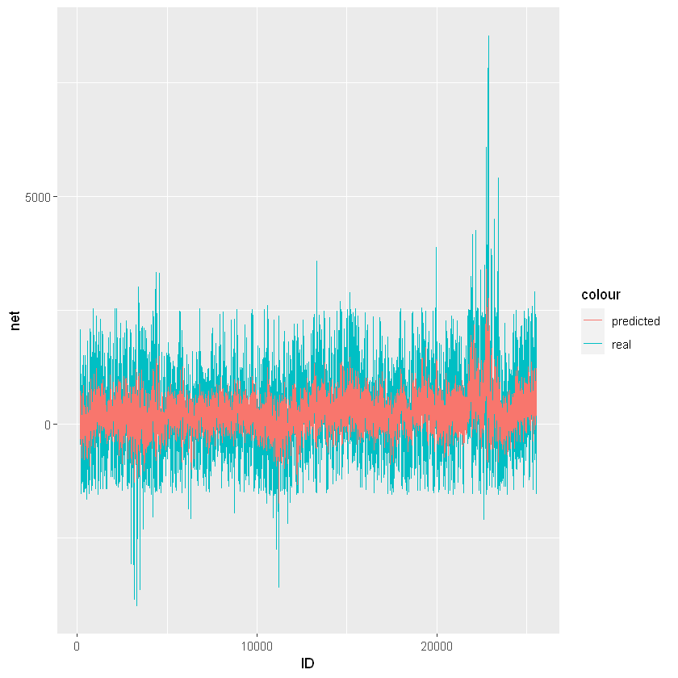

```r
ggplot(train, aes(x=ID))+
geom_line(aes(y=net, color="real"))+
geom_line(aes(y=predict(comb1,train), color = 'predicted'))
```

## EBLR Approach

At this step, decision trees are constructed on the residuals of the fitted linear regression model. For simplification, maximum depth of the decision trees are set to 4. After constructing the decision trees, one or several binary variables are added to the model in order to further explain the residuals. This iterative process is continued until there are no further improvements to the linear regression model.

Results of the first decision tree on the residuals of the linear regression is as follows:

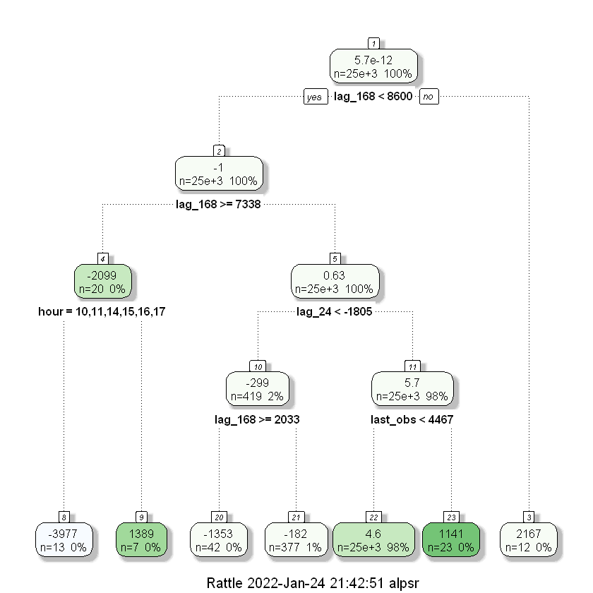

```r
train[,Residuals1 := predict(comb1, train) - net]
tree1 = rpart(Residuals1 ~ hour + is_monday + is_wday + is_friday + is_saturday + is_sunday + lag_24 + lag_168 + last_obs,
              train,control=rpart.control(cp=0,maxdepth=4))
fancyRpartPlot(tree1)
```

A binary variable which denotes the cases with lag_168 between 8600 and 7338 and hour in 10,11,14,15,16,17 are added to the model. Then, a new linear regression model is constructed. As a result, adjusted R-squared improved to 21.47%. Then a new decision tree is formed on the new residuals.

```r
comb2 <- lm(net ~ ID + hour + is_monday + is_wday + is_friday + is_saturday +
            is_sunday + lag_24 + lag_168 + last_obs + Binary1, train)
summary(comb2)
```

```
Call:
lm(formula = net ~ ID + hour + is_monday + is_wday + is_friday +
    is_saturday + is_sunday + lag_24 + lag_168 + last_obs + Binary1,
    data = train)

Residuals:
    Min      1Q  Median      3Q     Max
-5892.8  -485.8   -19.5   461.2  5657.7

Coefficients: (1 not defined because of singularities)
              Estimate Std. Error t value Pr(>|t|)
(Intercept) -1.477e+02  2.708e+01  -5.452 5.01e-08 ***
ID           5.549e-03  6.593e-04   8.417  < 2e-16 ***
hour1        1.137e+02  3.246e+01   3.502 0.000462 ***
hour2        6.112e+01  3.244e+01   1.884 0.059572 .
hour3       -2.002e+00  3.243e+01  -0.062 0.950786
hour4       -8.643e+01  3.250e+01  -2.659 0.007835 **
hour5       -1.008e+02  3.250e+01  -3.103 0.001919 **
hour6       -1.819e+02  3.261e+01  -5.578 2.46e-08 ***
hour7       -7.561e+01  3.245e+01  -2.330 0.019824 *
hour8       -2.273e+01  3.246e+01  -0.700 0.483775
hour9        1.433e+02  3.247e+01   4.412 1.03e-05 ***
hour10       1.338e+02  3.247e+01   4.122 3.76e-05 ***
hour11       2.220e+02  3.252e+01   6.826 8.95e-12 ***
hour12       1.298e+02  3.245e+01   4.001 6.33e-05 ***
hour13       9.010e+01  3.244e+01   2.777 0.005484 **
hour14       2.288e+02  3.253e+01   7.034 2.06e-12 ***
hour15       2.348e+02  3.252e+01   7.220 5.34e-13 ***
hour16       2.050e+02  3.249e+01   6.309 2.86e-10 ***
hour17       2.215e+02  3.252e+01   6.812 9.87e-12 ***
hour18       1.980e+02  3.251e+01   6.090 1.14e-09 ***
hour19       1.897e+02  3.251e+01   5.833 5.51e-09 ***
hour20       1.716e+02  3.251e+01   5.278 1.32e-07 ***
hour21       1.939e+02  3.253e+01   5.959 2.57e-09 ***
hour22       1.317e+02  3.248e+01   4.054 5.06e-05 ***
hour23       1.120e+02  3.246e+01   3.451 0.000560 ***
is_monday    2.790e+02  1.767e+01  15.787  < 2e-16 ***
is_wday      1.815e+02  1.443e+01  12.572  < 2e-16 ***
is_friday    1.148e+02  1.762e+01   6.514 7.44e-11 ***
is_saturday  1.102e+02  1.757e+01   6.270 3.67e-10 ***
is_sunday           NA         NA      NA       NA
lag_24       1.661e-01  4.922e-03  33.746  < 2e-16 ***
lag_168      1.452e-01  4.790e-03  30.311  < 2e-16 ***
last_obs     1.949e-01  6.497e-03  29.994  < 2e-16 ***
Binary1      4.100e+03  2.100e+02  19.519  < 2e-16 ***
---
Signif. codes:  0 '***' 0.001 '**' 0.01 '*' 0.05 '.' 0.1 ' ' 1

Residual standard error: 745.9 on 25359 degrees of freedom
Multiple R-squared:  0.2157,	Adjusted R-squared:  0.2147
F-statistic: 217.9 on 32 and 25359 DF,  p-value: < 2.2e-16
```

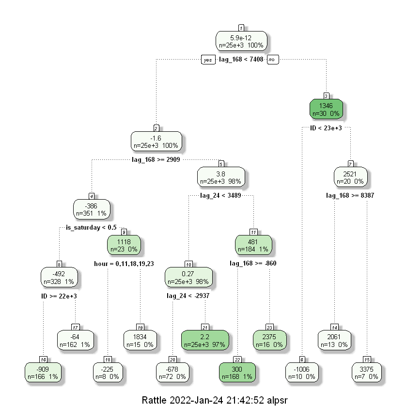

```r
train[,Residuals2 := predict(comb2, train) - net]
tree2 = rpart(Residuals2 ~ ID + hour + is_monday + is_wday + is_friday +
              is_saturday + is_sunday + lag_24 + lag_168 + last_obs + Binary1,
              train,control=rpart.control(cp=0,maxdepth=4))
fancyRpartPlot(tree2)
```

Three new binary variables are added to the model corresponding to the cases with highest average residuals. Then, a new model is constructed. The resulting model's adjusted R-squared value improved to 21.98%.

```r
comb3 <- lm(net ~ ID + hour + is_monday + is_wday + is_friday + is_saturday +
            is_sunday + lag_24 + lag_168 + last_obs + Binary1 + Binary2 + Binary3 + Binary4, train)
summary(comb3)
```

```
Call:
lm(formula = net ~ ID + hour + is_monday + is_wday + is_friday +
    is_saturday + is_sunday + lag_24 + lag_168 + last_obs + Binary1 +
    Binary2 + Binary3 + Binary4, data = train)

Residuals:
    Min      1Q  Median      3Q     Max
-5904.9  -486.6   -20.4   460.2  5670.8

Coefficients: (3 not defined because of singularities)
              Estimate Std. Error t value Pr(>|t|)
(Intercept) -1.521e+02  2.700e+01  -5.635 1.77e-08 ***
ID           5.701e-03  6.573e-04   8.674  < 2e-16 ***
hour1        1.133e+02  3.235e+01   3.501 0.000465 ***
hour2        6.091e+01  3.233e+01   1.884 0.059598 .
hour3       -1.989e+00  3.233e+01  -0.062 0.950938
hour4       -8.615e+01  3.240e+01  -2.659 0.007836 **
hour5       -1.005e+02  3.240e+01  -3.102 0.001923 **
hour6       -1.812e+02  3.251e+01  -5.574 2.51e-08 ***
hour7       -7.514e+01  3.235e+01  -2.323 0.020184 *
hour8       -2.260e+01  3.235e+01  -0.699 0.484775
hour9        1.427e+02  3.237e+01   4.408 1.05e-05 ***
hour10       1.332e+02  3.236e+01   4.116 3.87e-05 ***
hour11       2.232e+02  3.242e+01   6.886 5.88e-12 ***
hour12       1.339e+02  3.235e+01   4.138 3.51e-05 ***
hour13       9.433e+01  3.234e+01   2.917 0.003534 **
hour14       2.300e+02  3.242e+01   7.095 1.33e-12 ***
hour15       2.383e+02  3.242e+01   7.352 2.01e-13 ***
hour16       2.087e+02  3.238e+01   6.445 1.18e-10 ***
hour17       2.250e+02  3.242e+01   6.942 3.95e-12 ***
hour18       2.016e+02  3.241e+01   6.221 5.01e-10 ***
hour19       1.910e+02  3.241e+01   5.893 3.84e-09 ***
hour20       1.729e+02  3.241e+01   5.336 9.61e-08 ***
hour21       1.928e+02  3.243e+01   5.946 2.78e-09 ***
hour22       1.309e+02  3.237e+01   4.044 5.27e-05 ***
hour23       1.115e+02  3.235e+01   3.445 0.000571 ***
is_monday    2.816e+02  1.762e+01  15.986  < 2e-16 ***
is_wday      1.825e+02  1.439e+01  12.687  < 2e-16 ***
is_friday    1.176e+02  1.756e+01   6.696 2.18e-11 ***
is_saturday  1.171e+02  1.753e+01   6.679 2.46e-11 ***
is_sunday           NA         NA      NA       NA
lag_24       1.725e-01  4.931e-03  34.991  < 2e-16 ***
lag_168      1.414e-01  4.783e-03  29.565  < 2e-16 ***
last_obs     1.944e-01  6.476e-03  30.022  < 2e-16 ***
Binary1      4.118e+03  2.094e+02  19.667  < 2e-16 ***
Binary2     -2.416e+03  1.875e+02 -12.888  < 2e-16 ***
Binary3             NA         NA      NA       NA
Binary4             NA         NA      NA       NA
---
Signif. codes:  0 '***' 0.001 '**' 0.01 '*' 0.05 '.' 0.1 ' ' 1

Residual standard error: 743.4 on 25358 degrees of freedom
Multiple R-squared:  0.2208,	Adjusted R-squared:  0.2198
F-statistic: 217.7 on 33 and 25358 DF,  p-value: < 2.2e-16
```

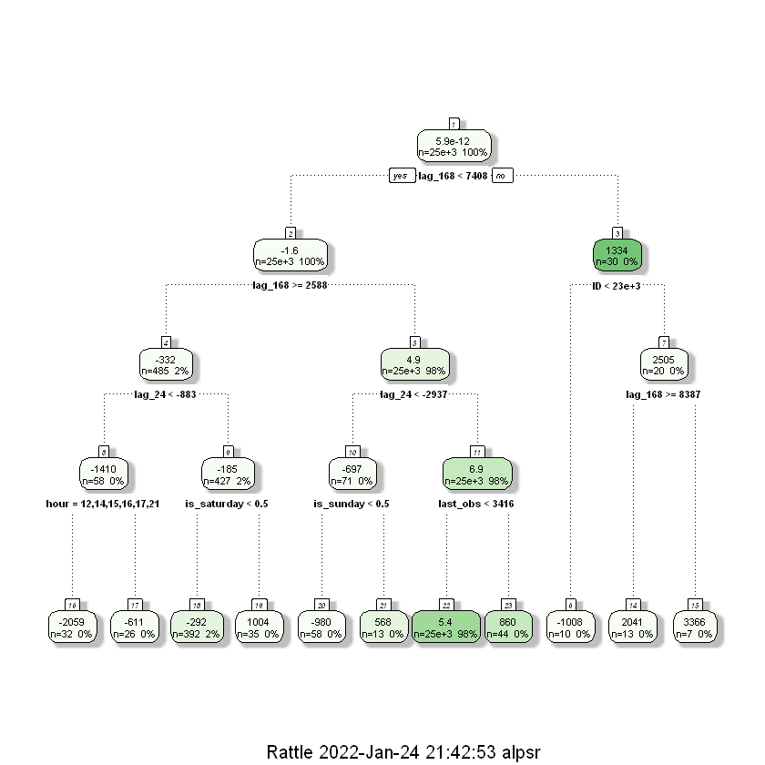

```r
fancyRpartPlot(tree3)
```

In conclusion, six binary variables are added to the model with the use of decision trees. Summary of the model is displayed below.

```r
summary(comb4)
```

```
Call:
lm(formula = net ~ ID + hour + is_monday + is_wday + is_friday +
    is_saturday + is_sunday + lag_24 + lag_168 + last_obs + Binary1 +
    Binary2 + Binary3 + Binary4 + Binary5 + Binary6, data = train)

Residuals:
    Min      1Q  Median      3Q     Max
-5359.3  -486.7   -19.4   458.8  5576.1

Coefficients: (3 not defined because of singularities)
              Estimate Std. Error t value Pr(>|t|)
(Intercept) -1.507e+02  2.690e+01  -5.600 2.17e-08 ***
ID           5.680e-03  6.549e-04   8.673  < 2e-16 ***
hour1        1.115e+02  3.224e+01   3.460 0.000542 ***
hour2        6.001e+01  3.222e+01   1.863 0.062525 .
hour3       -2.290e+00  3.221e+01  -0.071 0.943334
hour4       -8.594e+01  3.228e+01  -2.662 0.007770 **
hour5       -9.990e+01  3.228e+01  -3.095 0.001973 **
hour6       -1.792e+02  3.239e+01  -5.534 3.17e-08 ***
hour7       -7.327e+01  3.223e+01  -2.273 0.023032 *
hour8       -2.275e+01  3.224e+01  -0.706 0.480499
hour9        1.394e+02  3.226e+01   4.323 1.55e-05 ***
hour10       1.301e+02  3.225e+01   4.035 5.48e-05 ***
hour11       2.214e+02  3.230e+01   6.853 7.40e-12 ***
hour12       1.343e+02  3.224e+01   4.165 3.12e-05 ***
hour13       9.731e+01  3.222e+01   3.020 0.002530 **
hour14       2.297e+02  3.231e+01   7.111 1.18e-12 ***
hour15       2.375e+02  3.230e+01   7.353 2.00e-13 ***
hour16       2.082e+02  3.227e+01   6.453 1.12e-10 ***
hour17       2.237e+02  3.230e+01   6.924 4.50e-12 ***
hour18       2.030e+02  3.230e+01   6.284 3.35e-10 ***
hour19       1.894e+02  3.230e+01   5.864 4.58e-09 ***
hour20       1.701e+02  3.229e+01   5.266 1.41e-07 ***
hour21       1.895e+02  3.231e+01   5.865 4.55e-09 ***
hour22       1.273e+02  3.226e+01   3.947 7.93e-05 ***
hour23       1.088e+02  3.224e+01   3.375 0.000738 ***
is_monday    2.781e+02  1.756e+01  15.839  < 2e-16 ***
is_wday      1.793e+02  1.434e+01  12.507  < 2e-16 ***
is_friday    1.185e+02  1.750e+01   6.772 1.29e-11 ***
is_saturday  1.141e+02  1.747e+01   6.533 6.55e-11 ***
is_sunday           NA         NA      NA       NA
lag_24       1.722e-01  4.914e-03  35.040  < 2e-16 ***
lag_168      1.542e-01  4.880e-03  31.597  < 2e-16 ***
last_obs     1.953e-01  6.454e-03  30.257  < 2e-16 ***
Binary1      6.622e+03  2.875e+02  23.036  < 2e-16 ***
Binary2     -2.396e+03  1.868e+02 -12.825  < 2e-16 ***
Binary3             NA         NA      NA       NA
Binary4             NA         NA      NA       NA
Binary5     -3.152e+03  2.729e+02 -11.549  < 2e-16 ***
Binary6     -1.820e+03  1.972e+02  -9.230  < 2e-16 ***
---
Signif. codes:  0 '***' 0.001 '**' 0.01 '*' 0.05 '.' 0.1 ' ' 1

Residual standard error: 740.8 on 25356 degrees of freedom
Multiple R-squared:  0.2263,	Adjusted R-squared:  0.2252
F-statistic: 211.9 on 35 and 25356 DF,  p-value: < 2.2e-16
```

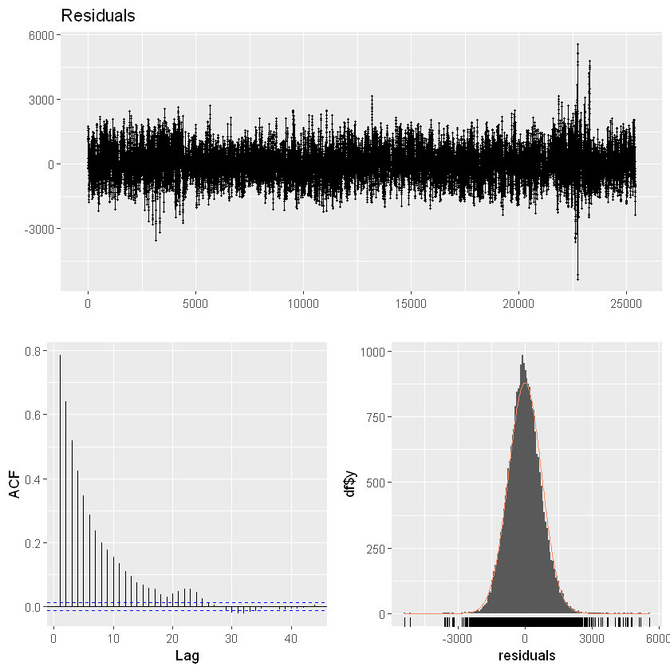

```r
checkresiduals(comb4$residuals)
```

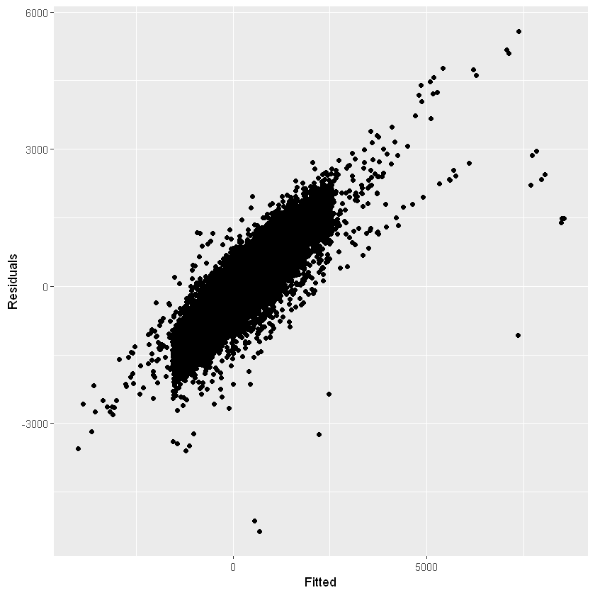

```r
ggplot(train, aes(x=net))+
geom_point(aes(y = comb4$residuals))+
labs(y = "Residuals")+
labs(x = "Fitted")
```

The model has a very large WMAPE value which means that the predictions from the model may not be reliable. Then, the outputs of the model are used to make a classification over the test period with a sliding window approach, the following confusion matrix is obtained. Although the model has a high accuracy with approximately 70%, it fails to account for the negative cases and always predicts positive values which means there is a significant bias in the model. Thus, the model achieves this high accuracy through the unbalanced nature of the data set and has a very low precision.

```r
train[, Final_Predict := predict(comb4, train)]
perf_dt("EBLR",train$net,train$Final_Predict)
```

A data.frame: 1 × 9

| name <chr> | n <int> | mean <dbl> | sd <dbl> | FBias <dbl> | MAPE <dbl> | RMSE <dbl> | MAD <dbl> | WMAPE <dbl> |
| --- | --- | --- | --- | --- | --- | --- | --- | --- |
| EBLR | 25392 | 273.4027 | 841.6478 | -2.157312e-14 | Inf | 4.645743 | 577.0092 | 2.110474 |

```r
confusionMatrix(data = as.factor(est_directions), reference = as.factor(real_directions), mode = "prec_recall")
```

```
Confusion Matrix and Statistics

          Reference
Prediction  -1   0   1
        -1   0   0   0
        0    0   0   0
        1   37  11 120

Overall Statistics

               Accuracy : 0.7143
                 95% CI : (0.6396, 0.7812)
    No Information Rate : 0.7143
    P-Value [Acc > NIR] : 0.5388

                  Kappa : 0

 Mcnemar's Test P-Value : NA

Statistics by Class:

                     Class: -1 Class: 0 Class: 1
Precision                   NA       NA   0.7143
Recall                  0.0000  0.00000   1.0000
F1                          NA       NA   0.8333
Prevalence              0.2202  0.06548   0.7143
Detection Rate          0.0000  0.00000   0.7143
Detection Prevalence    0.0000  0.00000   1.0000
Balanced Accuracy       0.5000  0.50000   0.5000
```

## KNN with different distance calculations

In this approach, the main objective is to determine which distance calculation gives the best accuracy performance in the dataset. One of the problem in this model is to calculation of the distance matrix. Computationally it is impossible to get a distance matrix for all instances. So, a train set is selected to get performance of the K-Nearest Neighbor algorithm. To make it realistic train set is selected before determined test starting day (2021-12-01). In addition, 14 days is selected to get a reasonable size and feasible computation range. As mentioned before, the main aim is to determine whether difference distance calculation has any impact on the model is the major objective to analysis. Weather dataset with principal components, day, and lagged values are used in the input dataset. Tried distance calculations are as follows:

- Euclidean distance when k=2,5,10
- DTW distance + no window when k=2,5,10
- DTW distance + window.type='sakoechiba' + window.size=10 when k=2,5,10
- DTW distance + window.type='sakoechiba' + window.size=20 when k=2,5,10
- LCSS + epsilon=0.05 + no window when k=2,5,10
- LCSS + epsilon=0.1 + no window when k=2,5,10
- ERP + gap penalty=0.5 + no window when k=2,5,10
- ERP + gap penalty=1 + no window when k=2,5,10

In addition, "Cross-validation to evaluate alternative classification strategies" Notebook is used to get these performance values. Namely, the performance of the models has been evaluated with cross-validation with fixed test indices to get better comparison results.

### Obtained results

```r
overall_results=rbindlist(result)
overall_results[,list(avg_acc=mean(acc),sdev_acc=sd(acc),result_count=.N),by=list(approach,k)]
```

| approach | k | avg_acc | sdev_acc | result_count |
| --- | --- | --- | --- | --- |
| project_dtw_raw_dist.csv | 2 | 0.6430769 | 0.06964976 | 100 |
| project_dtw_raw_dist.csv | 5 | 0.6802294 | 0.05341675 | 100 |
| project_dtw_raw_dist.csv | 10 | 0.7200742 | 0.03903751 | 100 |
| project_dtw_raw_dist_sakoe_10.csv | 2 | 0.6430769 | 0.06964976 | 100 |
| project_dtw_raw_dist_sakoe_10.csv | 5 | 0.6802294 | 0.05341675 | 100 |
| project_dtw_raw_dist_sakoe_10.csv | 10 | 0.7200742 | 0.03903751 | 100 |
| project_dtw_raw_dist_sakoe_20.csv | 2 | 0.6430769 | 0.06964976 | 100 |
| project_dtw_raw_dist_sakoe_20.csv | 5 | 0.6802294 | 0.05341675 | 100 |
| project_dtw_raw_dist_sakoe_20.csv | 10 | 0.7200742 | 0.03903751 | 100 |
| project_erp_raw_gap_005.csv | 2 | 0.6399798 | 0.06650581 | 100 |
| project_erp_raw_gap_005.csv | 5 | 0.6909312 | 0.04906949 | 100 |
| project_erp_raw_gap_005.csv | 10 | 0.7182456 | 0.04072530 | 100 |
| project_erp_raw_gap_1.csv | 2 | 0.6402227 | 0.06567888 | 100 |
| project_erp_raw_gap_1.csv | 5 | 0.6846829 | 0.04848222 | 100 |
| project_erp_raw_gap_1.csv | 10 | 0.7198178 | 0.03875830 | 100 |
| project_euc_raw_dist.csv | 2 | 0.6328745 | 0.06607764 | 100 |
| project_euc_raw_dist.csv | 5 | 0.6764035 | 0.05660061 | 100 |
| project_euc_raw_dist.csv | 10 | 0.7133131 | 0.04276158 | 100 |
| project_lcss_raw_epsilon_005.csv | 2 | 0.6087045 | 0.05901520 | 100 |
| project_lcss_raw_epsilon_005.csv | 5 | 0.7085290 | 0.02832335 | 100 |
| project_lcss_raw_epsilon_005.csv | 10 | 0.7319771 | 0.01909082 | 100 |
| project_lcss_raw_epsilon_01.csv | 2 | 0.6241430 | 0.05959275 | 100 |
| project_lcss_raw_epsilon_01.csv | 5 | 0.7114440 | 0.03103907 | 100 |
| project_lcss_raw_epsilon_01.csv | 10 | 0.7333198 | 0.01551811 | 100 |

### The best 8 distance types

```r
head(res_dt[order(avg_acc,decreasing = TRUE)], 8)
```

| approach | k | avg_acc | sdev_acc | result_count |
| --- | --- | --- | --- | --- |
| project_lcss_raw_epsilon_01.csv | 10 | 0.7333198 | 0.01551811 | 100 |
| project_lcss_raw_epsilon_005.csv | 10 | 0.7319771 | 0.01909082 | 100 |
| project_dtw_raw_dist.csv | 10 | 0.7200742 | 0.03903751 | 100 |
| project_dtw_raw_dist_sakoe_10.csv | 10 | 0.7200742 | 0.03903751 | 100 |
| project_dtw_raw_dist_sakoe_20.csv | 10 | 0.7200742 | 0.03903751 | 100 |
| project_erp_raw_gap_1.csv | 10 | 0.7198178 | 0.03875830 | 100 |
| project_erp_raw_gap_005.csv | 10 | 0.7182456 | 0.04072530 | 100 |
| project_euc_raw_dist.csv | 10 | 0.7133131 | 0.04276158 | 100 |

By looking this table, it can be said that there is no huge difference in between the performance of the models. In addition, calculation of distance matrix is much faster than others, which directed us to use euclidean distance calculations in the KNN models. K is selected 10 for the predictions by looking at the best models' k value.

### Performance of the KNN by using instances at 2021

```r
confusionMatrix(data = as.factor(class_predictions$predicted), reference = as.factor(all_dt[(nrow(all_dt)-335):nrow(all_dt)]$system_direction), mode = "prec_recall")
```

```
Confusion Matrix and Statistics

          Reference
Prediction Negative Neutral Positive
  Negative       40       7       30
  Neutral         2       5        2
  Positive       28      17      205

Overall Statistics

               Accuracy : 0.744
                 95% CI : (0.6939, 0.7899)
    No Information Rate : 0.7054
    P-Value [Acc > NIR] : 0.065910

                  Kappa : 0.3979

 Mcnemar's Test P-Value : 0.002103

Statistics by Class:

                     Class: Negative Class: Neutral Class: Positive
Precision                     0.5195        0.55556          0.8200
Recall                        0.5714        0.17241          0.8650
F1                            0.5442        0.26316          0.8419
Prevalence                    0.2083        0.08631          0.7054
Detection Rate                0.1190        0.01488          0.6101
Detection Prevalence          0.2292        0.02679          0.7440
Balanced Accuracy             0.7162        0.57969          0.7052
```

Obtained accuracy value is 0.744 with this approach. One of the problems in this problem is having an imbalanced target variable, which causes a tendency to predict positive. In order to overcome this problem, an alternative approach is tried to get better performance in the model.

## KNN with Sax Representation

As mentioned in previous approach, an alternative approach to overcome this problem is tried. By knowing outliers can disturb the model, sax representation will be used. In addition, 10 different class with equal probability will be created by using cut function to overcome imbalance problem in target variable. Class information and their actual values as follows:

- 1, 2, 3 are Negative Class (30%)
- 4 is Neutral Class (10%)
- 5, 6, 7, 8, 9, 10 are Positive Class (60%)

After predicting these 10 classes a conversion process will be applied to get actual target variables.

### Obtained Result with 10 Classes

```r
table(actual=res_dt$actual,  predicted=res_dt$predicted)
```

```
      predicted
actual 1 2 3 4 5 6 7 8 9 10
    1  0 2 1 1 0 0 1 1 2  1
    2  2 2 2 3 1 0 2 3 1  0
    3  3 3 1 7 2 4 1 1 4  1
    4  6 5 6 6 4 6 7 4 3  0
    5  3 3 8 4 1 1 1 1 1  2
    6  3 8 7 8 2 4 4 0 0  1
    7  1 2 5 7 3 5 3 3 5  1
    8  7 6 8 5 5 4 6 4 2  4
    9  5 4 6 9 2 8 4 6 4  3
    10 0 0 2 6 1 2 9 3 6  9
```

It is hard to understand the performance of the model by looking at this table. In addition, it can be misleading when converted actual target variable type. So, the converted version must be controlled. Predictions after conversion are as follows:

### Obtained Result with 10 Classes after Conversion

```r
confusionMatrix(data = as.factor(res_dt$converted_pred), reference = as.factor(res_dt$actual_req), mode = "prec_recall")
```

```
Confusion Matrix and Statistics

          Reference
Prediction Negative Neutral Positive
  Negative       28       8       83
  Neutral        15       6       40
  Positive       27      15      114

Overall Statistics

               Accuracy : 0.4405
                 95% CI : (0.3866, 0.4954)
    No Information Rate : 0.7054
    P-Value [Acc > NIR] : 1

                  Kappa : 0.0404

 Mcnemar's Test P-Value : 4.006e-09

Statistics by Class:

                     Class: Negative Class: Neutral Class: Positive
Precision                    0.23529        0.09836          0.7308
Recall                       0.40000        0.20690          0.4810
F1                           0.29630        0.13333          0.5802
Prevalence                   0.20833        0.08631          0.7054
Detection Rate               0.08333        0.01786          0.3393
Detection Prevalence         0.35417        0.18155          0.4643
Balanced Accuracy            0.52895        0.51387          0.5284
```

There is a certain performance decrease, so this approach will be ignored. Much as problem imbalance tried to be handled, decrease in performance is too big to neglect. One of the reasons for the decrease in performance can be explained by insufficient feature size to distinguish classes.

# Conclusion

In this project, the aim was to predict the sign of the imbalance in the Turkish Electricity Markets. Several classification and regression models are constructed. In the regression, first the "net imbalance" is forecasted, then the sign of the forecast is used for classification. Time series information about the past imbalances, the past meteorological measurements and breakdown data to create features. Then, performance of these models are evaluated over the test period. The performance of these models are considerable affected by the imbalanced nature of the target variable. In other words, "Positive" labeled instances comprised the majority of the data set which resulted in low precision for the "Negative" labeled cases.

Numerous approaches are considered for the classification problem which was explained in the previous sections. No single model has performed significantly better than the other models. We have achieved a training accuracy of 73.33% with k-NN classifier on LCSS distance with epsilon = 0.1 adn k = 10 on the raw time series. On the other hand, we have achieved an accuracy of approximately 70% with the k-NN classifier using the windowed time series and node information created using the decision trees. Also, with this approach we have achieved a relatively better precision on the negative values. However, since there are multiple models which resulted in similar accuracies, while making our predictions, we have considered several of them at the same time. We have also tried to adress the imbalance problem with the use of SAX representation which divides the data into equal probability classes.

Possible extensions to this study includes the addition of the past forecasted weather measurements. With this data we can compared the deviations of the real weather measurements from the predicted measurements which can then be used to explain the errors in the electricity production and consumption forecasts. These errors result in the imbalances in the electricity markets. Also, we can use the oversampling and undersampling methods to counter the imbalanced nature of the data set. Finally, more advanced algorithms such as random forests, XGBoosting and SVM can be used to construct more accurate models. In conclusion, although there is still room for improvement, we have achieved to increase the baseline method's accuracy to approximately 70%.

# Codes

### Repository of Project: https://github.com/mbahadir/IE48B_project_files

Breakdown Data Notebook: https://github.com/mbahadir/IE48B_project_files/blob/main/Breakdown_Data.ipynb  
Breakdown Data R File: https://github.com/mbahadir/IE48B_project_files/blob/main/Breakdown_Data.r

Data Control in Python Notebook: https://github.com/mbahadir/IE48B_project_files/blob/main/Data%20Control%20in%20Python.ipynb  
Data Control in Python File: https://github.com/mbahadir/IE48B_project_files/blob/main/Data%20Control%20in%20Python.py

Data Control in R Notebook: https://github.com/mbahadir/IE48B_project_files/blob/main/Data%20Control%20in%20R.ipynb  
Data Control in R File: https://github.com/mbahadir/IE48B_project_files/blob/main/Data%20Control%20in%20R.r

KNN Files Notebook: https://github.com/mbahadir/IE48B_project_files/blob/main/KNN%20Files.ipynb  
KNN Files R File: https://github.com/mbahadir/IE48B_project_files/blob/main/KNN%20Files.r

Sax Representation with KNN Notebook: https://github.com/mbahadir/IE48B_project_files/blob/main/Sax%20Representation%20with%20KNN.ipynb  
Sax Representation with KNN R File: https://github.com/mbahadir/IE48B_project_files/blob/main/Sax%20Representation%20with%20KNN.r

Linear Regression Final Notebook: https://github.com/mbahadir/IE48B_project_files/blob/main/Linear%20Regression%20Final.ipynb  
Linear Regression Final R File: https://github.com/mbahadir/IE48B_project_files/blob/main/Linear%20Regression%20Final.r

Decision Tree - Final Notebook: https://github.com/mbahadir/IE48B_project_files/blob/main/Decision%20Tree%20-%20Final.ipynb  
Decision Tree - Final R File: https://github.com/mbahadir/IE48B_project_files/blob/main/Decision%20Tree%20-%20Final.r

Weather Data Set Notebook: https://github.com/mbahadir/IE48B_project_files/blob/main/Weather%20Data%20Set.ipynb  
Weather Data Set R File: https://github.com/mbahadir/IE48B_project_files/blob/main/Weather%20Data%20Set.r